# Bayesian FE fractional polynomial NMA for grouped survival data

Sandro Gsteiger

2020-08-25

## Prepare the environment

```r
library(dplyr)
library(gemtc)
library(gemtcPlus)
library(ggmcmc)
```

## Load in the data

```r
data("grouped_TTE")
```

## Plan the model

```r
model_plan <-  plan_fp(model.pars = list(exponents = 0, t.eval = "midpoint"),
                       bth.model = "FE", ref.std = "STUDY2", nma.ref.trt = "B",
                       n.chains = 2,
                       n.iter = 6000,
                       n.burnin = 1000,
                       n.thin = 1
                       )
```

## Ready the data

```r
# Returns list list contaiing a jags list ready for input to `nma_fit` and a network object
model_input <- nma_pre_proc(grouped_TTE, model_plan)
```

**Figure** Network graph

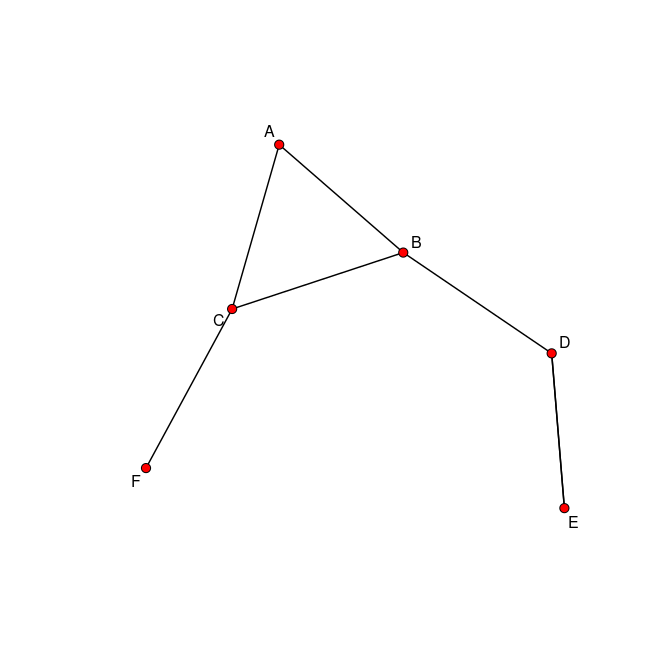

```r
plot(model_input$network, displaylabels = TRUE)
```

## Fit the model

```r
model  <- nma_fit(model_input = model_input)
```

## Post processing

```r
# Prepare plot data
nodes <- colnames(as.mcmc(model)[[1]])
sel <- grep("d[2,", nodes, fixed = TRUE)
plot_data <- ggs(as.mcmc(model)[, sel])
```

Produce diagnostic plots to further assess convergence. Here: select the contrasts trt 2 vs trt 1 for visibility.

**Figure** Traceplot

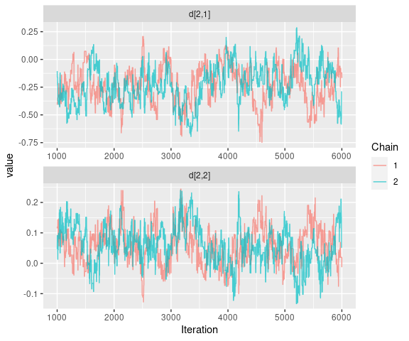

```r
ggs_traceplot(plot_data)
```

**Figure** Densityplot

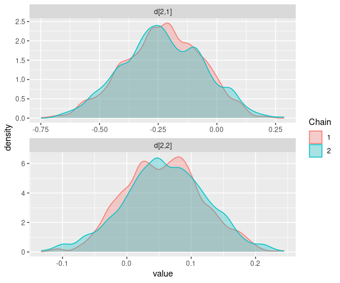

```r
ggs_density(plot_data)
```

**Figure** Auto-correlation plot

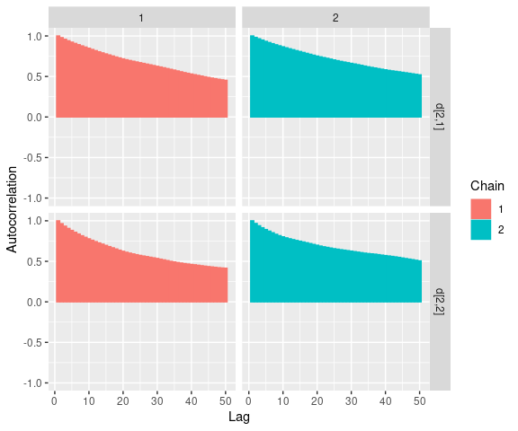

```r
ggs_autocorrelation(plot_data)
```

**Figure** Running means

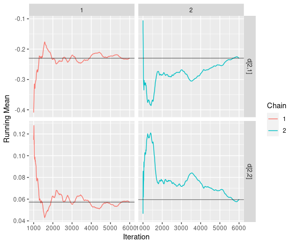

```r
ggs_running(plot_data)
```

Save the FE results for later use.

```r
res_fe1 <- model
rm(model)
```

# Second order fractional polynomial, fixed effect model

Create a new model plan and re-run the fit.

## Plan the model

```r
model_plan <-  plan_fp(model.pars = list(exponents = c(0, 1), t.eval = "midpoint"),
                       bth.model = "FE", ref.std = "STUDY2", nma.ref.trt = "B",
                       n.chains = 2,
                       n.iter = 6000,
                       n.burnin = 1000,
                       n.thin = 1, descr = "Second order fractional polynomial model (fixed effect)"
                       )
```

## Ready the data

```r
# Returns list list contaiing a jags list ready for input to `nma_fit` and a network object
model_input <- nma_pre_proc(grouped_TTE,  model_plan)
```

## Fit the model

```r
model  <- nma_fit(model_input = model_input)
```

Produce diagnostic plots to further assess convergence. Here: select the contrasts trt 2 vs trt 1 for visibility.

## Post processing

```r
# Prepare plot data
nodes <- colnames(as.mcmc(model)[[1]])
sel <- grep("d[2,", nodes, fixed = TRUE)
plot_data <- ggs(as.mcmc(model)[, sel])
```

**Figure** Traceplot

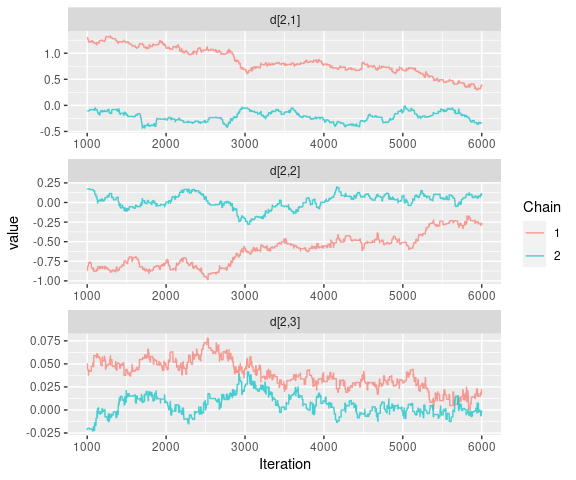

```r
ggs_traceplot(plot_data)
```

The chains are obviously MUCH too short!

Save the results for later use.

```r
res_fe2 <- model
rm(model)
```

# Produce outputs of interest

Start with an object collecting all fits.

```r
all_res <- list(res_fe1, res_fe2)
```

## Model comparison

```r
dcompare <- get_fp_comparison(all_res)
cat("__Table__ Model comparison")
```

**Table** Model comparison

```r
pander::pandoc.table(dcompare, row.names = FALSE, split.tables = Inf)
```

[output not shown]

## Hazard ratio estimates

```r
# loop through fits
for(i in seq_along(all_res)){
  res_i <- all_res[[i]]
  title <- res_i$descr
  cat("### ", title, "  \n")


  ## Tables: Hazard ratio estimates for each segment

  HR_rev <- get_fp_HR(x = seq(0.1, 24, 0.1),
                      fit = res_i,
                      trt.nos = 1:res_i$data.jg$Ntrt,
                      ref.no = 2, # use this treatment in the list of treatments as reference for the HRs
                      revert = TRUE # revert to get HRs ref vs other treatments
                      )

  fig1 <- plot_fp_HR(HR_rev, xlab = "Month", breaks = c(0.25, 0.5, 1, 2))
  fig2 <- plot_fp_HR(HR_rev, xlab = "Month", breaks = c(0.25, 0.5, 1, 2), facet = TRUE) # !! HERE: ADD CIs !!


  dHRtab <- HR_rev %>%
    mutate(Month = round(x, 1)) %>%        # trick, otherwise equality testing fails to pick out all timepoints in filter step
    filter(Month %in% seq(3, 24, 3)) %>%
    mutate(Comparison = lab, Month, HR = round(median, 3), lCI = round(lCI, 3), uCI = round(uCI, 3)) %>%
    select(Comparison, Month, HR, lCI, uCI)


  cat("__Figure__ Hazard ratios treatment A vs other treatments\n")
  plot(fig1)
  cat("\n\n")
  cat("__Figure__ Hazard ratios treatment A vs other treatments (multi-panel)\n")
  plot(fig2)
  cat("\n\n")
  cat("__Table__ Hazard ratios treatment A vs other treatments\n")
  pander::pandoc.table(dHRtab, row.names = FALSE, split.tables = Inf)
  cat("\n\n")
  cat("\n\n")

  rm(HR_rev)
  rm(dHRtab)
  rm(fig1)
  rm(fig2)
  rm(res_i)
}
```

### Fractional polynomial model

**Figure** Hazard ratios treatment A vs other treatments

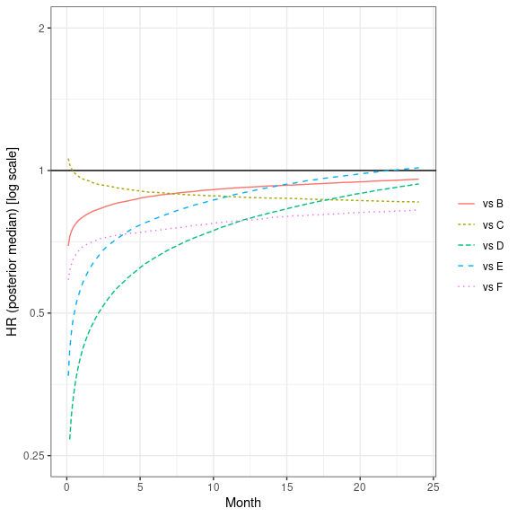

**Figure** Hazard ratios treatment A vs other treatments (multi-panel)

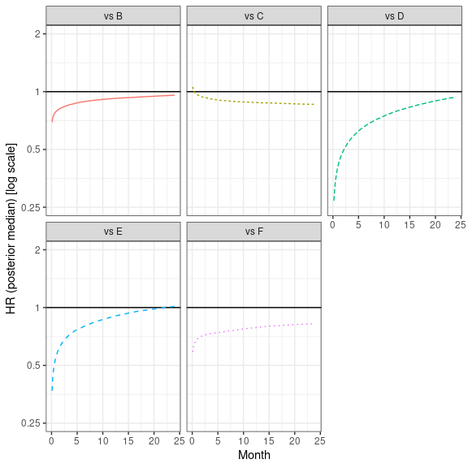

**Table** Hazard ratios treatment A vs other treatments

| Comparison | Month | HR | lCI | uCI |
| --- | --- | --- | --- | --- |
| A vs B | 3 | 0.846 | 0.684 | 1.044 |
| A vs B | 6 | 0.884 | 0.755 | 1.034 |
| A vs B | 9 | 0.906 | 0.781 | 1.042 |
| A vs B | 12 | 0.921 | 0.793 | 1.056 |
| A vs B | 15 | 0.931 | 0.801 | 1.076 |
| A vs B | 18 | 0.94 | 0.807 | 1.096 |
| A vs B | 21 | 0.95 | 0.808 | 1.113 |
| A vs B | 24 | 0.959 | 0.81 | 1.137 |
| A vs C | 3 | 0.924 | 0.686 | 1.235 |
| A vs C | 6 | 0.9 | 0.715 | 1.144 |
| A vs C | 9 | 0.887 | 0.708 | 1.108 |
| A vs C | 12 | 0.878 | 0.696 | 1.105 |
| A vs C | 15 | 0.873 | 0.681 | 1.111 |
| A vs C | 18 | 0.867 | 0.667 | 1.119 |
| A vs C | 21 | 0.862 | 0.653 | 1.129 |
| A vs C | 24 | 0.858 | 0.64 | 1.143 |
| A vs D | 3 | 0.545 | 0.389 | 0.833 |
| A vs D | 6 | 0.655 | 0.506 | 0.887 |
| A vs D | 9 | 0.726 | 0.571 | 0.942 |
| A vs D | 12 | 0.786 | 0.609 | 1.011 |
| A vs D | 15 | 0.83 | 0.633 | 1.088 |
| A vs D | 18 | 0.87 | 0.649 | 1.161 |
| A vs D | 21 | 0.906 | 0.659 | 1.233 |
| A vs D | 24 | 0.937 | 0.662 | 1.302 |
| A vs E | 3 | 0.702 | 0.466 | 1.14 |
| A vs E | 6 | 0.791 | 0.59 | 1.11 |
| A vs E | 9 | 0.85 | 0.65 | 1.15 |
| A vs E | 12 | 0.897 | 0.676 | 1.204 |
| A vs E | 15 | 0.935 | 0.686 | 1.264 |
| A vs E | 18 | 0.967 | 0.684 | 1.317 |
| A vs E | 21 | 0.992 | 0.68 | 1.384 |
| A vs E | 24 | 1.014 | 0.682 | 1.445 |
| A vs F | 3 | 0.726 | 0.389 | 1.307 |
| A vs F | 6 | 0.747 | 0.491 | 1.176 |
| A vs F | 9 | 0.767 | 0.537 | 1.142 |
| A vs F | 12 | 0.783 | 0.547 | 1.137 |
| A vs F | 15 | 0.8 | 0.552 | 1.152 |
| A vs F | 18 | 0.809 | 0.554 | 1.18 |
| A vs F | 21 | 0.818 | 0.548 | 1.216 |
| A vs F | 24 | 0.826 | 0.536 | 1.259 |

### Second order fractional polynomial model (fixed effect)

**Figure** Hazard ratios treatment A vs other treatments

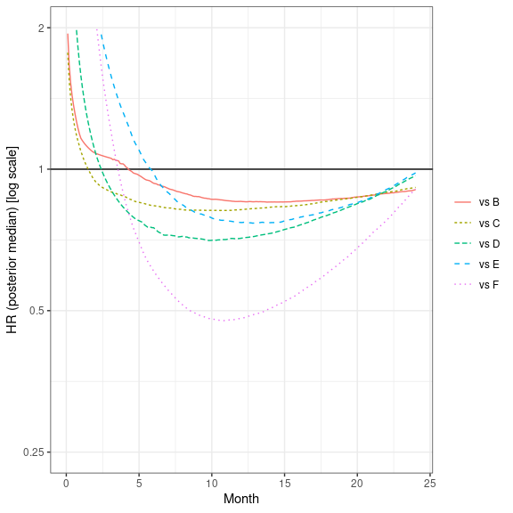

**Figure** Hazard ratios treatment A vs other treatments (multi-panel)

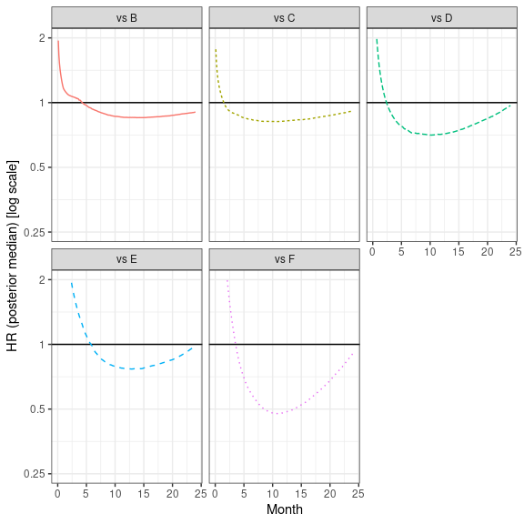

**Table** Hazard ratios treatment A vs other treatments

| Comparison | Month | HR | lCI | uCI |
| --- | --- | --- | --- | --- |
| A vs B | 3 | 1.057 | 0.722 | 1.639 |
| A vs B | 6 | 0.933 | 0.729 | 1.127 |
| A vs B | 9 | 0.874 | 0.709 | 1.058 |
| A vs B | 12 | 0.854 | 0.683 | 1.047 |
| A vs B | 15 | 0.852 | 0.673 | 1.059 |
| A vs B | 18 | 0.861 | 0.692 | 1.068 |
| A vs B | 21 | 0.88 | 0.709 | 1.08 |
| A vs B | 24 | 0.904 | 0.736 | 1.114 |
| A vs C | 3 | 0.897 | 0.682 | 1.533 |
| A vs C | 6 | 0.836 | 0.654 | 1.121 |
| A vs C | 9 | 0.818 | 0.64 | 1.067 |
| A vs C | 12 | 0.82 | 0.635 | 1.066 |
| A vs C | 15 | 0.832 | 0.647 | 1.076 |
| A vs C | 18 | 0.854 | 0.669 | 1.097 |
| A vs C | 21 | 0.881 | 0.685 | 1.146 |
| A vs C | 24 | 0.915 | 0.686 | 1.229 |
| A vs D | 3 | 0.913 | 0.508 | 3.888 |
| A vs D | 6 | 0.751 | 0.493 | 2.275 |
| A vs D | 9 | 0.712 | 0.517 | 1.625 |
| A vs D | 12 | 0.713 | 0.566 | 1.245 |
| A vs D | 15 | 0.744 | 0.578 | 1.048 |
| A vs D | 18 | 0.799 | 0.554 | 1.143 |
| A vs D | 21 | 0.868 | 0.521 | 1.334 |
| A vs D | 24 | 0.969 | 0.491 | 1.582 |
| A vs E | 3 | 1.612 | 0.852 | 12.29 |
| A vs E | 6 | 0.982 | 0.616 | 3.973 |
| A vs E | 9 | 0.805 | 0.55 | 2.077 |
| A vs E | 12 | 0.77 | 0.559 | 1.363 |
| A vs E | 15 | 0.776 | 0.563 | 1.088 |
| A vs E | 18 | 0.815 | 0.534 | 1.144 |
| A vs E | 21 | 0.872 | 0.507 | 1.333 |
| A vs E | 24 | 0.982 | 0.472 | 1.598 |
| A vs F | 3 | 1.241 | 0.669 | 2.116 |
| A vs F | 6 | 0.607 | 0.408 | 1.016 |
| A vs F | 9 | 0.491 | 0.334 | 0.802 |
| A vs F | 12 | 0.482 | 0.323 | 0.758 |
| A vs F | 15 | 0.524 | 0.354 | 0.794 |
| A vs F | 18 | 0.603 | 0.405 | 0.914 |
| A vs F | 21 | 0.729 | 0.492 | 1.118 |
| A vs F | 24 | 0.907 | 0.59 | 1.509 |

## Survivor function estimates

The NMA baseline estimate from the `ref_trt` arm from `ref_std` is used. These are combined with the time-varying hazard-ratio functions from the NMA to obtain the survivor functions for the other interventions.

```r
ref_trt <- "B"
ref_std <- "STUDY2"
hor <- 60

# loop through fits
for(i in seq_along(all_res)){
  res_i <- all_res[[i]]
  title <- res_i$descr
  cat("### ", title, "  \n")

  ## Plots of survivor functions over time ("NMA result"), ref study/arm and timehorizons specified in settings function
  sel_ref <- which(attr(res_i$data.jg, "d_arms")$study == ref_std & attr(res_i$data.jg, "d_arms")$treatment == ref_trt)
  id_ref_std <- attr(res_i$data.jg, "d_arms")$studyn[sel_ref]
  id_ref_arm <- attr(res_i$data.jg, "d_arms")$arm[sel_ref]

  S_extrap <- get_fp_S(fit = res_i,
                       ref.std = id_ref_std,
                       ref.arm = id_ref_arm,
                       time = seq(0.1, hor, 0.1))

  fig <- ggplot(data = S_extrap) +
    geom_line(aes(x = time, y = S, col = treatment, linetype = treatment)) +
    ylim(0, 1) +
    xlab("Month") + ylab("Survival probability") +
    theme_bw() +
    theme(legend.title = element_blank())
  cat("__Figure__ Survivor function estimates (time horizon:", hor, "months) \n")
  plot(fig)
  cat("\n\n")

  fig <- ggplot(data = S_extrap) +
    facet_wrap(~treatment) +
    geom_ribbon(aes(x = time, ymin = lCrI, ymax = uCrI), fill = "lightblue", alpha = 0.8) +
    geom_line(aes(x = time, y = S)) +
    ylim(0, 1) +
    xlab("Month") + ylab("Survival probability") +
    theme_bw()
  cat("__Figure__ Survivor function estimates by treatment (time horizon:", hor, "months) \n")
  plot(fig)
  cat("\n\n")

  rm(list = c("S_extrap", "fig"))
  rm(res_i)
}
```

### Fractional polynomial model

**Figure** Survivor function estimates (time horizon: 60 months)

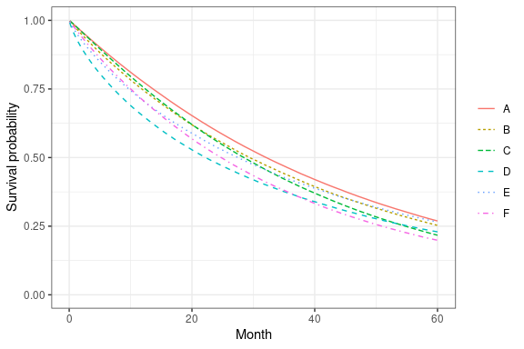

**Figure** Survivor function estimates by treatment (time horizon: 60 months)

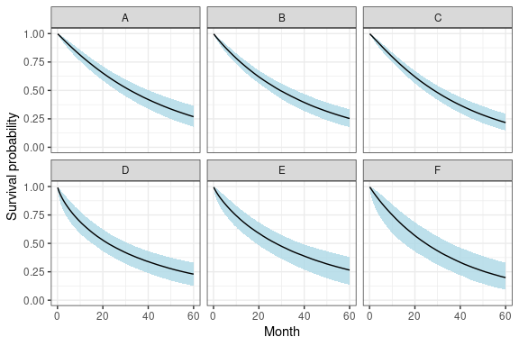

### Second order fractional polynomial model (fixed effect)

**Figure** Survivor function estimates (time horizon: 60 months)

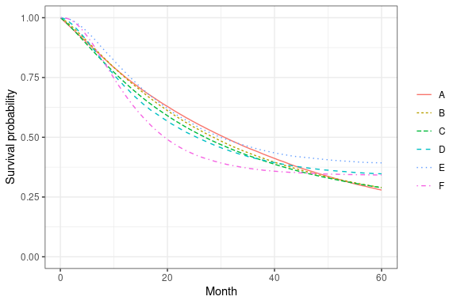

**Figure** Survivor function estimates by treatment (time horizon: 60 months)

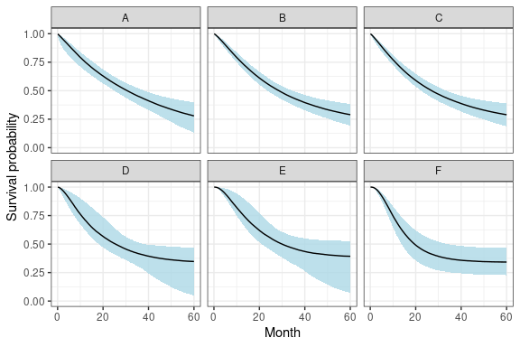

## Model fit: observed KM data vs estimated S(t)

For every arm in every study, the study baseline hazard estimate is combined with the corresponding contrast estimate (both from the NMA) to obtain the estimated survivor functions.

```r
hor <- 36
# loop through fits
for(i in seq_along(all_res)){
  res_i <- all_res[[i]]
  title <- res_i$descr
  cat("### ", title, "  \n")

  gof <- get_fp_GoF(fit = res_i, time = seq(0.1, hor, 0.1))

  fig <- ggplot() +
    geom_line(data = gof %>% filter(type == "nma"), aes(x = time, y = S, col = treatment)) +
    geom_line(data = gof %>% filter(type == "obs"), aes(x = time, y = S, col = treatment), linetype = "dashed") +
    facet_wrap(~study, ncol = 2) +
    ylim(0, 1) + xlim(0, 36) +
    xlab("Month") + ylab("Survival probability") +
    theme_bw() +
    theme(legend.position = "top", legend.title = element_blank())

  cat("__Figure__ Goodness-of-fit: estimated (solid lines) and observed (dashed) survivor functions for each study\n")
  plot(fig)
  cat("\n\n")

  rm(list = c("gof", "fig"))
  rm(res_i)
}
```

### Fractional polynomial model

**Figure** Goodness-of-fit: estimated (solid lines) and observed (dashed) survivor functions for each study

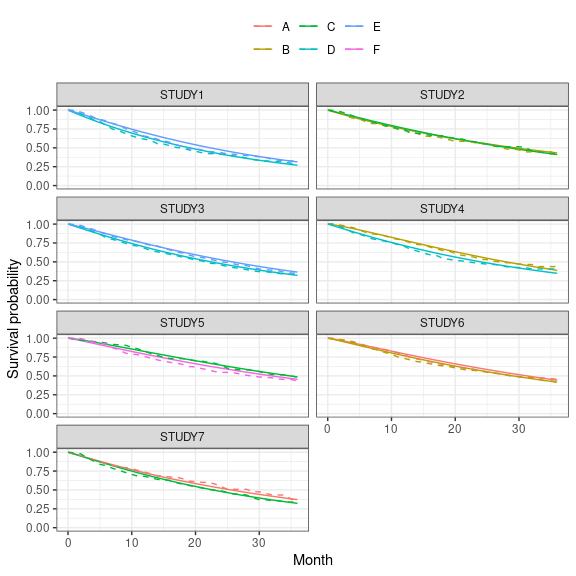

### Second order fractional polynomial model (fixed effect)

**Figure** Goodness-of-fit: estimated (solid lines) and observed (dashed) survivor functions for each study

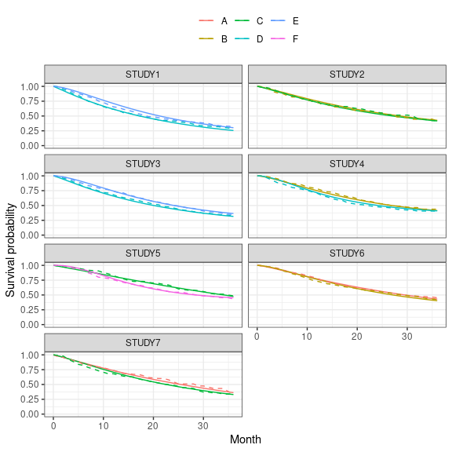

## Parameter estimates (baseline and contrasts)

```r
# loop through fits
for(i in seq_along(all_res)){
  res_i <- all_res[[i]]
  title <- res_i$descr
  cat("### ", title, "  \n")

  cest <- get_fp_contrasts(res_i)

  cat("\n\n")
  cat("__Table__ Contrast estimates in fractional polynomial vs network reference\n")
  pander::pandoc.table(cest, row.names = FALSE, split.tables = Inf)
  cat("\n\n")

  rm(cest)
  rm(res_i)
}
```

### Fractional polynomial model

**Table** Contrast estimates in fractional polynomial vs network reference

| Treatment | Int.med | Int.lCI | Int.uCI | Slope1.med | Slope1.lCI | Slope1.uCI |
| --- | --- | --- | --- | --- | --- | --- |
| A | -0.231 | -0.56 | 0.088 | 0.058 | -0.062 | 0.181 |
| C | -0.201 | -0.674 | 0.238 | 0.101 | -0.091 | 0.289 |
| D | 0.676 | 0.066 | 1.069 | -0.208 | -0.379 | 0.071 |
| E | 0.346 | -0.442 | 0.884 | -0.127 | -0.346 | 0.211 |
| F | 0.16 | -0.761 | 1.113 | -0.009 | -0.373 | 0.343 |

### Second order fractional polynomial model (fixed effect)

**Table** Contrast estimates in fractional polynomial vs network reference

| Treatment | Int.med | Int.lCI | Int.uCI | Slope1.med | Slope1.lCI | Slope1.uCI | Slope2.med | Slope2.lCI | Slope2.uCI |
| --- | --- | --- | --- | --- | --- | --- | --- | --- | --- |
| A | 0.143 | -0.382 | 1.235 | -0.232 | -0.881 | 0.151 | 0.018 | -0.01 | 0.063 |
| C | 0.208 | -0.373 | 0.685 | -0.112 | -0.335 | 0.327 | -0.001 | -0.033 | 0.03 |
| D | -0.253 | -1.072 | 0.33 | 0.345 | -0.12 | 0.716 | -0.05 | -0.072 | 0.064 |
| E | -1.229 | -3.053 | -0.515 | 0.961 | 0.667 | 1.11 | -0.072 | -0.102 | 0.019 |
| F | -1.154 | -2.174 | -0.47 | 1.303 | 0.67 | 2.093 | -0.128 | -0.189 | -0.058 |

## Posterior correlation plots

```r
# loop through fits
for(i in seq_along(all_res)){
  res_i <- all_res[[i]]
  title <- res_i$descr
  cat("### ", title, "  \n")

  corrs <- get_fp_corrs(res_i)

  for(j in 1:res_i$data.jg$Ntrt){
    cat("\n\n")
    cat("__Table__ Posterior correlations of (multivariate) contrasts for", dimnames(corrs)$treatment[j],"vs reference\n")
    pander::pandoc.table(corrs[j,,], row.names = dimnames(corrs[j,,])[[1]], split.tables = Inf)
    cat("\n\n")
  }

  rm(corrs)
  rm(res_i)
}
```

### Fractional polynomial model

**Table** Posterior correlations of (multivariate) contrasts for B vs reference

|  | Int | Slope1 |
| --- | --- | --- |
| **Int** | 1 | NA |
| **Slope1** | NA | 1 |

**Table** Posterior correlations of (multivariate) contrasts for A vs reference

|  | Int | Slope1 |
| --- | --- | --- |
| **Int** | 1 | -0.901 |
| **Slope1** | -0.901 | 1 |

**Table** Posterior correlations of (multivariate) contrasts for C vs reference

|  | Int | Slope1 |
| --- | --- | --- |
| **Int** | 1 | -0.877 |
| **Slope1** | -0.877 | 1 |

**Table** Posterior correlations of (multivariate) contrasts for D vs reference

|  | Int | Slope1 |
| --- | --- | --- |
| **Int** | 1 | -0.919 |
| **Slope1** | -0.919 | 1 |

**Table** Posterior correlations of (multivariate) contrasts for E vs reference

|  | Int | Slope1 |
| --- | --- | --- |
| **Int** | 1 | -0.925 |
| **Slope1** | -0.925 | 1 |

**Table** Posterior correlations of (multivariate) contrasts for F vs reference

|  | Int | Slope1 |
| --- | --- | --- |
| **Int** | 1 | -0.927 |
| **Slope1** | -0.927 | 1 |

### Second order fractional polynomial model (fixed effect)

**Table** Posterior correlations of (multivariate) contrasts for B vs reference

|  | Int | Slope1 | Slope2 |
| --- | --- | --- | --- |
| **Int** | 1 | NA | NA |
| **Slope1** | NA | 1 | NA |
| **Slope2** | NA | NA | 1 |

**Table** Posterior correlations of (multivariate) contrasts for A vs reference

|  | Int | Slope1 | Slope2 |
| --- | --- | --- | --- |
| **Int** | 1 | -0.97 | 0.863 |
| **Slope1** | -0.97 | 1 | -0.955 |
| **Slope2** | 0.863 | -0.955 | 1 |

**Table** Posterior correlations of (multivariate) contrasts for C vs reference

|  | Int | Slope1 | Slope2 |
| --- | --- | --- | --- |
| **Int** | 1 | -0.843 | 0.425 |
| **Slope1** | -0.843 | 1 | -0.805 |
| **Slope2** | 0.425 | -0.805 | 1 |

**Table** Posterior correlations of (multivariate) contrasts for D vs reference

|  | Int | Slope1 | Slope2 |
| --- | --- | --- | --- |
| **Int** | 1 | -0.333 | -0.537 |
| **Slope1** | -0.333 | 1 | -0.596 |
| **Slope2** | -0.537 | -0.596 | 1 |

**Table** Posterior correlations of (multivariate) contrasts for E vs reference

|  | Int | Slope1 | Slope2 |
| --- | --- | --- | --- |
| **Int** | 1 | -0.604 | -0.84 |
| **Slope1** | -0.604 | 1 | 0.12 |
| **Slope2** | -0.84 | 0.12 | 1 |

**Table** Posterior correlations of (multivariate) contrasts for F vs reference

|  | Int | Slope1 | Slope2 |
| --- | --- | --- | --- |
| **Int** | 1 | -0.85 | 0.553 |
| **Slope1** | -0.85 | 1 | -0.885 |
| **Slope2** | 0.553 | -0.885 | 1 |

# Appendix

````r
# loop through fits
for(i in seq_along(all_res)){
  res_i <- all_res[[i]]
  title <- res_i$descr
  cat("## ", title, "  \n\n")

  jginfo <- get_jags_info(res_i, include.comments = TRUE)
  cat("```\n", jginfo, "\n```\n\n")

  rm(jginfo)
  rm(out)
}
````

## Fractional polynomial model

[output not shown]

[output cut: 84 more lines]

## Second order fractional polynomial model (fixed effect)

[output not shown]

[output cut: 89 more lines]

# Session info

```r
date()
```

```
## [1] "Tue Aug 25 14:20:16 2020"
```